# Can you digit?

29-01-2016

## Outline

- Data
- Convolutional Neural Networks
- Recurrent Neural Networks
- Data augmentation
- Results

## Data

- TIDIGITS dataset
  - Recording of >300 people speaking the digits 0-9
  - Split between men, women, and children
  - Digits are repeated a number of times and in a number of combinations
- We use subsample of 10 speakers: 5 male, 5 female
  - Each person repeats every digit twice
  - Training set: 6 speakers (3 male and 3 female)
  - Test set: 4 speakers (2 male and 2 female)
  - Model trained on 132 sample audio files, tests on 88

[interactive chart not shown]

## Waveform

- raw signal
- 8000 Hz
- cropped and centered

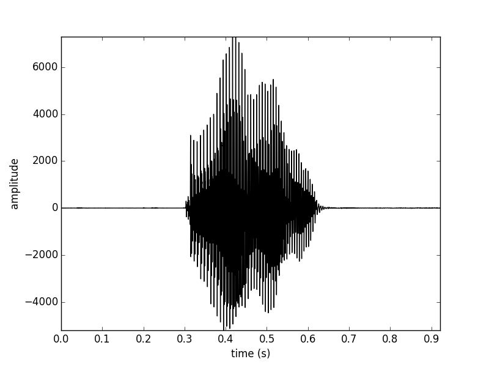

## Spectrogram

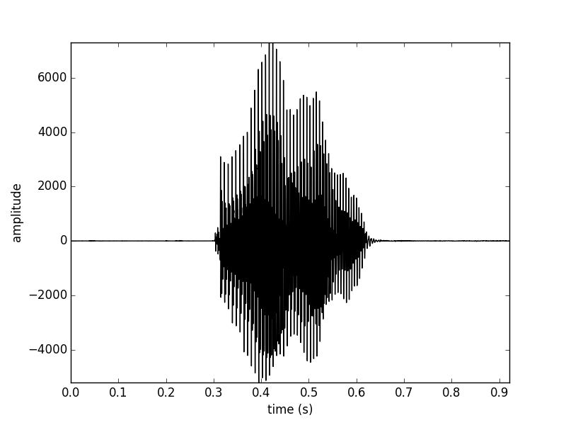

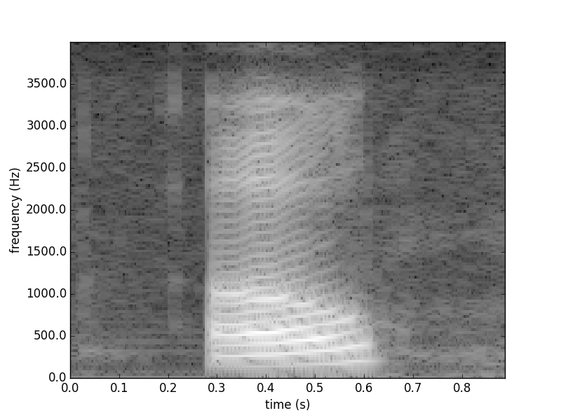

## Mel-Frequency Basis

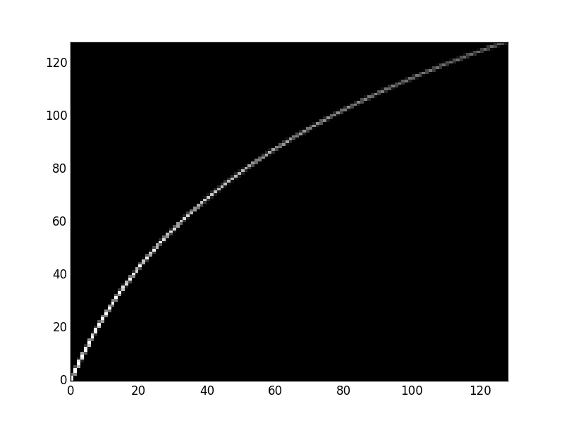

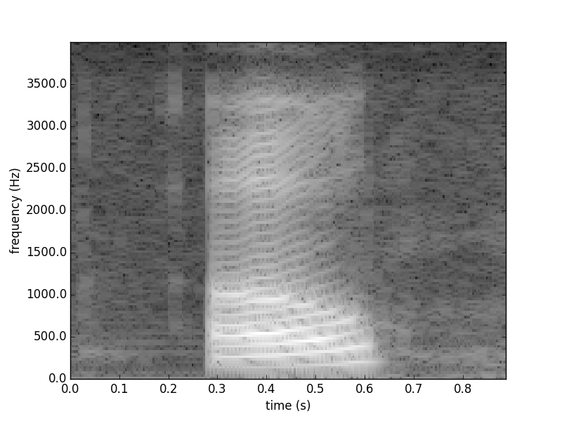

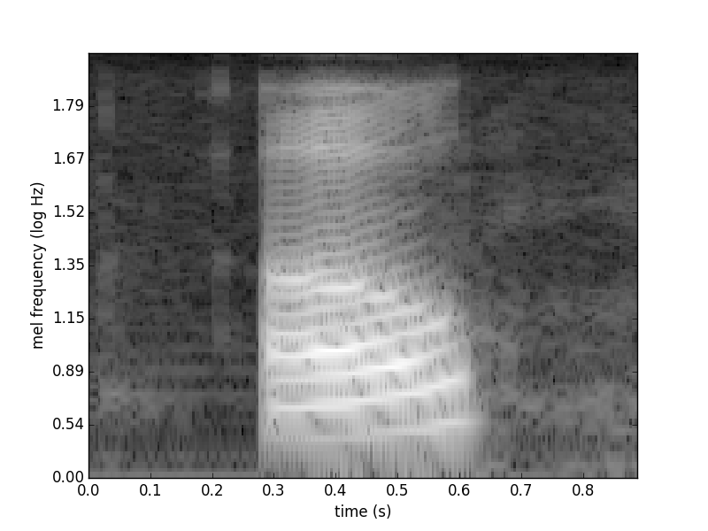

## Convolutional Neural Networks

Recall ANN

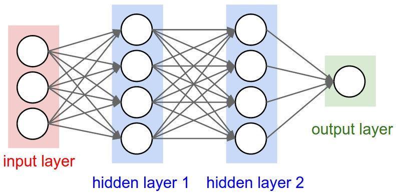

- too many parameters
- overfitting
- not scalable with large datasets
- Local features
- Translational invariance features (can occur at different position in the image)
- High-level features composed by low-level features

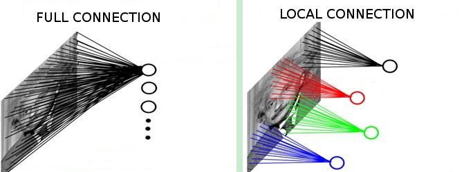

## Convolution

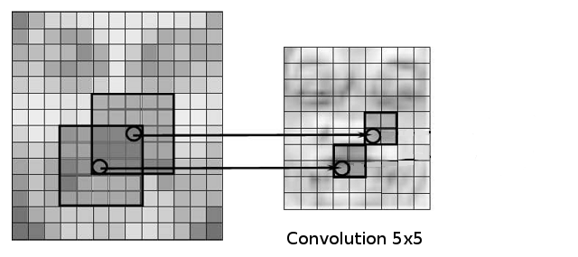

- Receptive Field
- Stride
- Padding
- ReLU: \(\max\{0, x\}\)

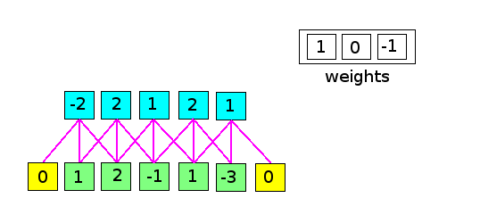

## Max Pooling

- Reduce spatial size of the representation
- Filter size [2x2], with stride of 2
- Discard 75 % of the activations

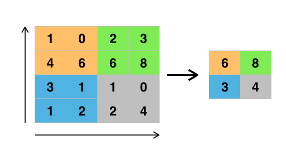

## Overall Architecture

- Input layer
- Convolution layer
- Fully connected layer

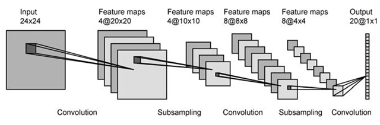

## Models

## CNN model

1. 4 x 4 convolution
2. 4 x 4 convolution
3. 2 x 4 max-pooling
4. three pairs of
   - 4 x 4 convolution
   - 2 x 2 max-pooling
5. A dense layer of 128 units
6. A dense layer of 11 units (for classification)

Each layer uses ReLU for the activation, except the final classification later, which uses softmax.

## RNN model

- first uses a convolution component, similar to the CNN model, to reduce the size of the spectrogram in the frequency domain
  - reduce the frequency domain by a factor of approximately 2^6 and the time domain by a factor of 4
- then, an LSTM with 256 units is used to iterate through the time domain
- final layer of LSTM fed into a fully connected layer reducing this to 11 modes, which as input to the softmax function for classification

## CNN Results

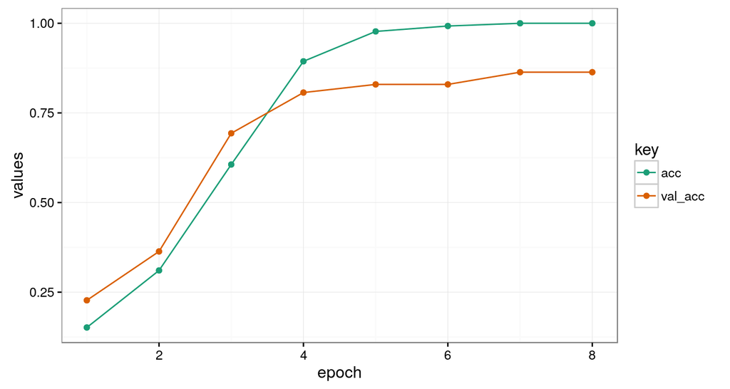

## Cross-Validation

- LOOCV
- 5 folds have test accuracy in 0.8636 - 1
- 5 folds have test accuracy 0.0909

## Dropout and Augmentation

- Experiment with adding dropout layers to prevent overfitting
- no appreciable improvement in test accuracy
- Augment the training set by introducing 10 copies of each sample, with each of these audio signals shifted by a small amount
- some improvement in test score, but still wide range (0.8750 - 0.9659)
- LOOCV still has five folds with 0.0909

## Optimisation Tuning

- Possible that high losses due to a learning rate that is too high
- Switch to Stochastic Gradient Descent, run for 20 epochs
- LOOCV average test accuracy 0.8636
- Test accuracy in the folds ranged from 0.4545 to 1.

## RNN results

- One run on unaugmented data using SGD optimiser and 100 epochs
- Test accuracy of 0.8864

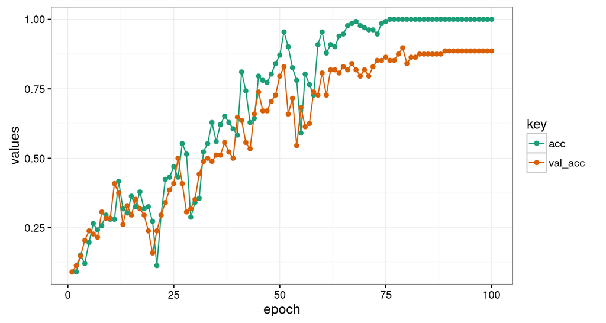